# ISLR Chapter 6 Labs on Model Selection and Regularization

S Zimine

11/13/2017

# Lab 1: Subset Selection Methods

```r
library(ISLR)
data(Hitters)
names(Hitters)
```

```
##  [1] "AtBat"     "Hits"      "HmRun"     "Runs"      "RBI"
##  [6] "Walks"     "Years"     "CAtBat"    "CHits"     "CHmRun"
## [11] "CRuns"     "CRBI"      "CWalks"    "League"    "Division"
## [16] "PutOuts"   "Assists"   "Errors"    "Salary"    "NewLeague"
```

We use the dataset Hitters containing features about baseball players and wish to predict the player’s `Salary`.

## Data Cleaning

We first need to check if we should clean the data. Checking for NA occurencies in data.

```r
dim(Hitters)
```

```
## [1] 322  20
```

```r
sum(is.na(Hitters$Salary))
```

```
## [1] 59
```

We do have missing `Salary` points. So lets clean the dataset.

```r
Hitters <- na.omit(Hitters)
dim(Hitters)
```

```
## [1] 263  20
```

```r
sum(is.na(Hitters))
```

```
## [1] 0
```

## Best Subset Selection

Use `regsubsets()` func from `leaps` package to perform best Subsets selection. We can do since our number of features is 19.

Doing best subset selection on the full dataset.

```r
library(leaps)
p_features<- dim(Hitters)[2] -1
p_features
```

```
## [1] 19
```

```r
regfit.full<-regsubsets(Salary~., data=Hitters, nvmax=p_features)
reg.summary<-summary(regfit.full)
reg.summary
```

```
## Subset selection object
## Call: regsubsets.formula(Salary ~ ., data = Hitters, nvmax = p_features)
## 19 Variables  (and intercept)
##            Forced in Forced out
## AtBat          FALSE      FALSE
## Hits           FALSE      FALSE
## HmRun          FALSE      FALSE
## Runs           FALSE      FALSE
## RBI            FALSE      FALSE
## Walks          FALSE      FALSE
## Years          FALSE      FALSE
## CAtBat         FALSE      FALSE
## CHits          FALSE      FALSE
## CHmRun         FALSE      FALSE
## CRuns          FALSE      FALSE
## CRBI           FALSE      FALSE
## CWalks         FALSE      FALSE
## LeagueN        FALSE      FALSE
## DivisionW      FALSE      FALSE
## PutOuts        FALSE      FALSE
## Assists        FALSE      FALSE
## Errors         FALSE      FALSE
## NewLeagueN     FALSE      FALSE
## 1 subsets of each size up to 19
## Selection Algorithm: exhaustive
##           AtBat Hits HmRun Runs RBI Walks Years CAtBat CHits CHmRun CRuns
## 1  ( 1 )  " "   " "  " "   " "  " " " "   " "   " "    " "   " "    " "
## 2  ( 1 )  " "   "*"  " "   " "  " " " "   " "   " "    " "   " "    " "
## 3  ( 1 )  " "   "*"  " "   " "  " " " "   " "   " "    " "   " "    " "
## 4  ( 1 )  " "   "*"  " "   " "  " " " "   " "   " "    " "   " "    " "
## 5  ( 1 )  "*"   "*"  " "   " "  " " " "   " "   " "    " "   " "    " "
## 6  ( 1 )  "*"   "*"  " "   " "  " " "*"   " "   " "    " "   " "    " "
## 7  ( 1 )  " "   "*"  " "   " "  " " "*"   " "   "*"    "*"   "*"    " "
## 8  ( 1 )  "*"   "*"  " "   " "  " " "*"   " "   " "    " "   "*"    "*"
## 9  ( 1 )  "*"   "*"  " "   " "  " " "*"   " "   "*"    " "   " "    "*"
## 10  ( 1 ) "*"   "*"  " "   " "  " " "*"   " "   "*"    " "   " "    "*"
## 11  ( 1 ) "*"   "*"  " "   " "  " " "*"   " "   "*"    " "   " "    "*"
## 12  ( 1 ) "*"   "*"  " "   "*"  " " "*"   " "   "*"    " "   " "    "*"
## 13  ( 1 ) "*"   "*"  " "   "*"  " " "*"   " "   "*"    " "   " "    "*"
## 14  ( 1 ) "*"   "*"  "*"   "*"  " " "*"   " "   "*"    " "   " "    "*"
```

[output cut: 10 more lines]

```
## 5  ( 1 )  "*"  " "    " "     "*"       "*"     " "     " "    " "
## 6  ( 1 )  "*"  " "    " "     "*"       "*"     " "     " "    " "
## 7  ( 1 )  " "  " "    " "     "*"       "*"     " "     " "    " "
## 8  ( 1 )  " "  "*"    " "     "*"       "*"     " "     " "    " "
## 9  ( 1 )  "*"  "*"    " "     "*"       "*"     " "     " "    " "
## 10  ( 1 ) "*"  "*"    " "     "*"       "*"     "*"     " "    " "
## 11  ( 1 ) "*"  "*"    "*"     "*"       "*"     "*"     " "    " "
## 12  ( 1 ) "*"  "*"    "*"     "*"       "*"     "*"     " "    " "
## 13  ( 1 ) "*"  "*"    "*"     "*"       "*"     "*"     "*"    " "
## 14  ( 1 ) "*"  "*"    "*"     "*"       "*"     "*"     "*"    " "
## 15  ( 1 ) "*"  "*"    "*"     "*"       "*"     "*"     "*"    " "
## 16  ( 1 ) "*"  "*"    "*"     "*"       "*"     "*"     "*"    " "
## 17  ( 1 ) "*"  "*"    "*"     "*"       "*"     "*"     "*"    "*"
## 18  ( 1 ) "*"  "*"    "*"     "*"       "*"     "*"     "*"    "*"
## 19  ( 1 ) "*"  "*"    "*"     "*"       "*"     "*"     "*"    "*"
```

```r
names(reg.summary)
```

```
## [1] "which"  "rsq"    "rss"    "adjr2"  "cp"     "bic"    "outmat" "obj"
```

Asteriks show the best selected features for a given `k`.

Lets explore $R^2$. Then plot RSS, adusted $R^2$, $C_p$ and $BIC$.

```r
reg.summary$rsq
```

```
##  [1] 0.3214501 0.4252237 0.4514294 0.4754067 0.4908036 0.5087146 0.5141227
##  [8] 0.5285569 0.5346124 0.5404950 0.5426153 0.5436302 0.5444570 0.5452164
## [15] 0.5454692 0.5457656 0.5459518 0.5460945 0.5461159
```

```r
par(mfrow=c(1,2))
plot(reg.summary$rss ,xlab="Number of Variables ",ylab="RSS",
type="l", main="Best subset select")
plot(reg.summary$adjr2 ,xlab="Number of Variables ",
ylab="Adjusted RSq",type="l", main="Best subset select")

idx_max<- which.max(reg.summary$adjr2)
paste("R-squared is at max with  number of features:",idx_max)
```

```
## [1] "R-squared is at max with  number of features: 11"
```

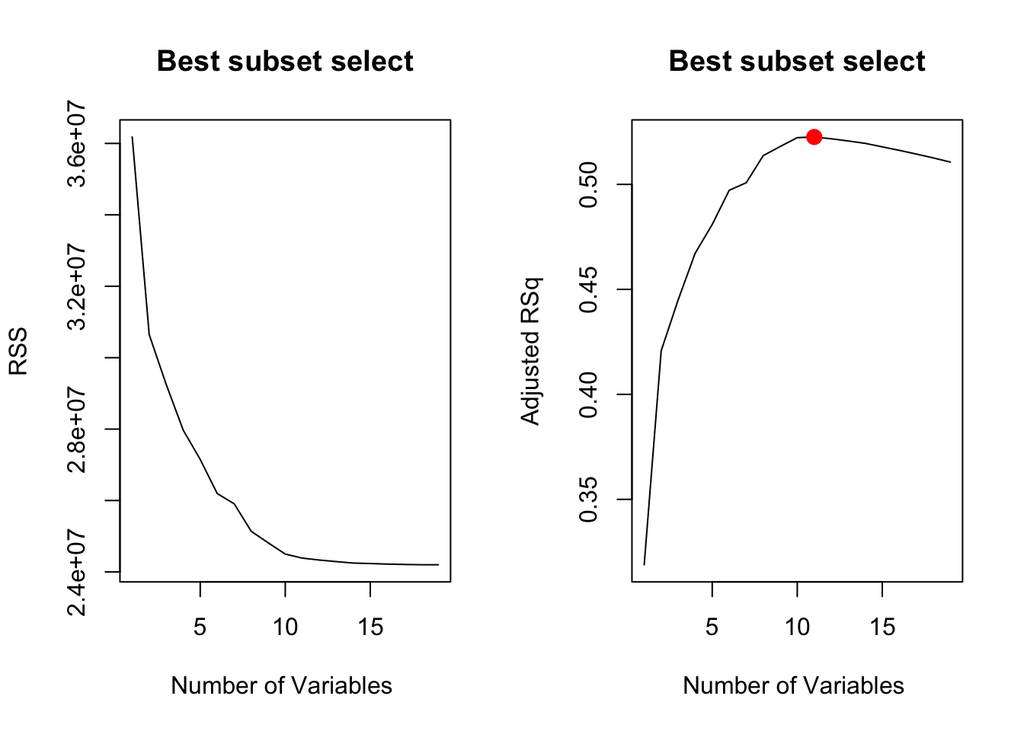

```r
points(idx_max,reg.summary$adjr2[idx_max],col="red", cex=2, pch=20)
```

In similar fashion lets plot $C_p$ and $BIC$ statitstics.

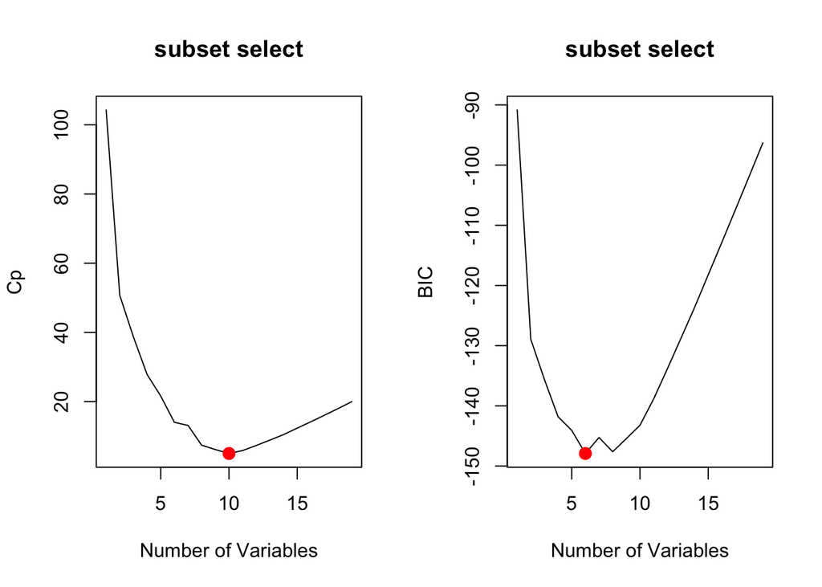

```r
par(mfrow=c(1,2))
plot(reg.summary$cp, xlab="Number of Variables", ylab="Cp",type="l", main="subset select")
cp_idx <- which.min(reg.summary$cp)
points(cp_idx,reg.summary$cp[cp_idx],col="red", cex=2, pch=20)

plot(reg.summary$bic, xlab="Number of Variables", ylab="BIC",type="l", main="subset select")
b_idx <- which.min(reg.summary$bic)
points(b_idx,reg.summary$bic[b_idx],col="red", cex=2, pch=20)
```

The `regsubsets()` has a built-in `plot()`.

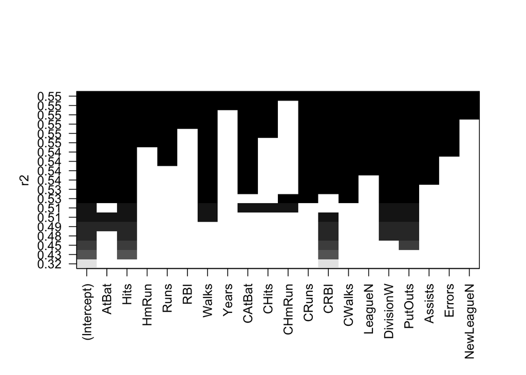

```r
plot(regfit.full,scale="r2")
```

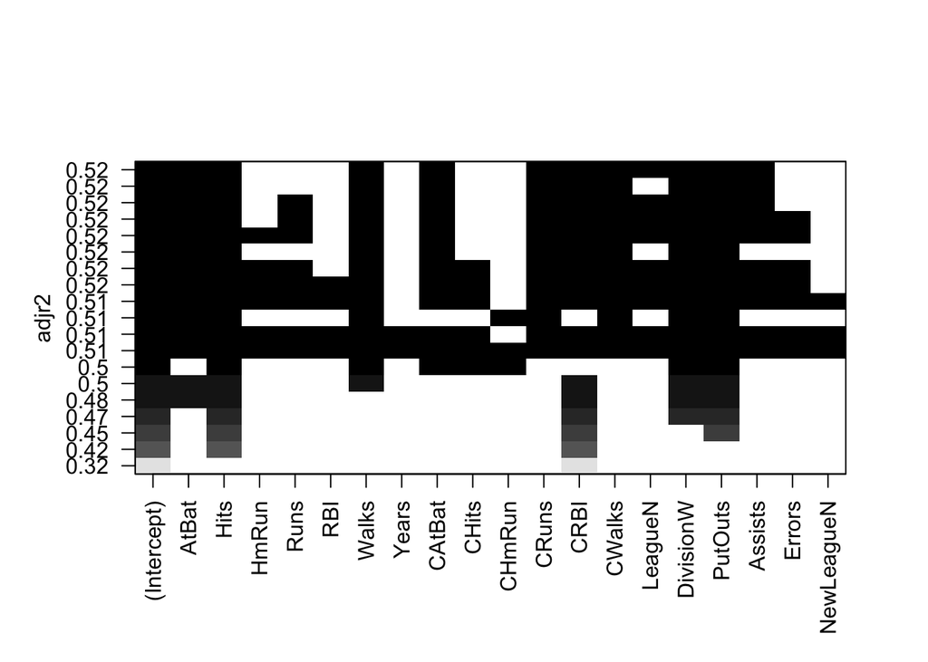

```r
plot(regfit.full,scale="adjr2")
```

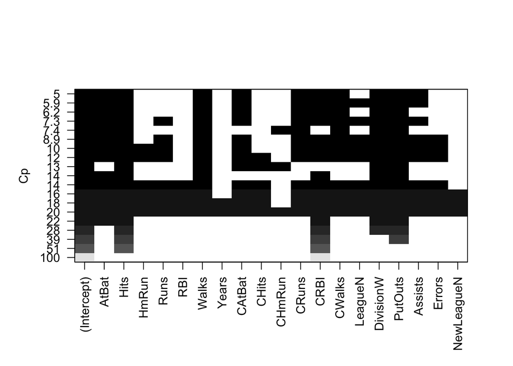

```r
plot(regfit.full,scale="Cp")
```

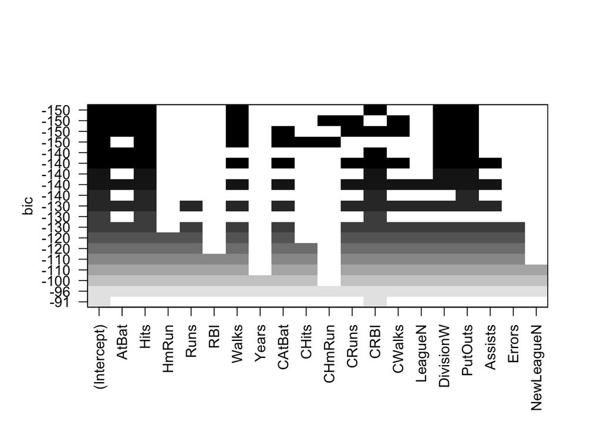

```r
plot(regfit.full,scale="bic")
```

Smallest BIC is for a model with 6 predictors. Print their coeffs

```r
coef(regfit.full,6)
```

```
##  (Intercept)        AtBat         Hits        Walks         CRBI
##   91.5117981   -1.8685892    7.6043976    3.6976468    0.6430169
##    DivisionW      PutOuts
## -122.9515338    0.2643076
```

### Forward and Backward Stepwise selection

`resubsets()` acn be also used to do forward and backwards stepwise selection

```r
p_features<- dim(Hitters)[2] -1
regfit.fwd<-regsubsets(Salary~., data=Hitters, nvmax=p_features,method="forward")
reg_f.summary<-summary(regfit.fwd)
reg_f.summary
```

```
## Subset selection object
## Call: regsubsets.formula(Salary ~ ., data = Hitters, nvmax = p_features,
##     method = "forward")
## 19 Variables  (and intercept)
##            Forced in Forced out
## AtBat          FALSE      FALSE
## Hits           FALSE      FALSE
## HmRun          FALSE      FALSE
## Runs           FALSE      FALSE
## RBI            FALSE      FALSE
## Walks          FALSE      FALSE
## Years          FALSE      FALSE
## CAtBat         FALSE      FALSE
## CHits          FALSE      FALSE
## CHmRun         FALSE      FALSE
## CRuns          FALSE      FALSE
## CRBI           FALSE      FALSE
## CWalks         FALSE      FALSE
## LeagueN        FALSE      FALSE
## DivisionW      FALSE      FALSE
## PutOuts        FALSE      FALSE
## Assists        FALSE      FALSE
## Errors         FALSE      FALSE
## NewLeagueN     FALSE      FALSE
## 1 subsets of each size up to 19
## Selection Algorithm: forward
##           AtBat Hits HmRun Runs RBI Walks Years CAtBat CHits CHmRun CRuns
## 1  ( 1 )  " "   " "  " "   " "  " " " "   " "   " "    " "   " "    " "
## 2  ( 1 )  " "   "*"  " "   " "  " " " "   " "   " "    " "   " "    " "
## 3  ( 1 )  " "   "*"  " "   " "  " " " "   " "   " "    " "   " "    " "
## 4  ( 1 )  " "   "*"  " "   " "  " " " "   " "   " "    " "   " "    " "
## 5  ( 1 )  "*"   "*"  " "   " "  " " " "   " "   " "    " "   " "    " "
## 6  ( 1 )  "*"   "*"  " "   " "  " " "*"   " "   " "    " "   " "    " "
## 7  ( 1 )  "*"   "*"  " "   " "  " " "*"   " "   " "    " "   " "    " "
## 8  ( 1 )  "*"   "*"  " "   " "  " " "*"   " "   " "    " "   " "    "*"
## 9  ( 1 )  "*"   "*"  " "   " "  " " "*"   " "   "*"    " "   " "    "*"
## 10  ( 1 ) "*"   "*"  " "   " "  " " "*"   " "   "*"    " "   " "    "*"
## 11  ( 1 ) "*"   "*"  " "   " "  " " "*"   " "   "*"    " "   " "    "*"
## 12  ( 1 ) "*"   "*"  " "   "*"  " " "*"   " "   "*"    " "   " "    "*"
## 13  ( 1 ) "*"   "*"  " "   "*"  " " "*"   " "   "*"    " "   " "    "*"
```

[output cut: 11 more lines]

```
## 5  ( 1 )  "*"  " "    " "     "*"       "*"     " "     " "    " "
## 6  ( 1 )  "*"  " "    " "     "*"       "*"     " "     " "    " "
## 7  ( 1 )  "*"  "*"    " "     "*"       "*"     " "     " "    " "
## 8  ( 1 )  "*"  "*"    " "     "*"       "*"     " "     " "    " "
## 9  ( 1 )  "*"  "*"    " "     "*"       "*"     " "     " "    " "
## 10  ( 1 ) "*"  "*"    " "     "*"       "*"     "*"     " "    " "
## 11  ( 1 ) "*"  "*"    "*"     "*"       "*"     "*"     " "    " "
## 12  ( 1 ) "*"  "*"    "*"     "*"       "*"     "*"     " "    " "
## 13  ( 1 ) "*"  "*"    "*"     "*"       "*"     "*"     "*"    " "
## 14  ( 1 ) "*"  "*"    "*"     "*"       "*"     "*"     "*"    " "
## 15  ( 1 ) "*"  "*"    "*"     "*"       "*"     "*"     "*"    " "
## 16  ( 1 ) "*"  "*"    "*"     "*"       "*"     "*"     "*"    " "
## 17  ( 1 ) "*"  "*"    "*"     "*"       "*"     "*"     "*"    "*"
## 18  ( 1 ) "*"  "*"    "*"     "*"       "*"     "*"     "*"    "*"
## 19  ( 1 ) "*"  "*"    "*"     "*"       "*"     "*"     "*"    "*"
```

```r
regfit.bwd<-regsubsets(Salary~., data=Hitters, nvmax=p_features,method="backward")
reg_b.summary<-summary(regfit.bwd)
reg_b.summary
```

```
## Subset selection object
## Call: regsubsets.formula(Salary ~ ., data = Hitters, nvmax = p_features,
##     method = "backward")
## 19 Variables  (and intercept)
##            Forced in Forced out
## AtBat          FALSE      FALSE
## Hits           FALSE      FALSE
## HmRun          FALSE      FALSE
## Runs           FALSE      FALSE
## RBI            FALSE      FALSE
## Walks          FALSE      FALSE
## Years          FALSE      FALSE
## CAtBat         FALSE      FALSE
## CHits          FALSE      FALSE
## CHmRun         FALSE      FALSE
## CRuns          FALSE      FALSE
## CRBI           FALSE      FALSE
## CWalks         FALSE      FALSE
## LeagueN        FALSE      FALSE
## DivisionW      FALSE      FALSE
## PutOuts        FALSE      FALSE
## Assists        FALSE      FALSE
## Errors         FALSE      FALSE
## NewLeagueN     FALSE      FALSE
## 1 subsets of each size up to 19
## Selection Algorithm: backward
##           AtBat Hits HmRun Runs RBI Walks Years CAtBat CHits CHmRun CRuns
## 1  ( 1 )  " "   " "  " "   " "  " " " "   " "   " "    " "   " "    "*"
## 2  ( 1 )  " "   "*"  " "   " "  " " " "   " "   " "    " "   " "    "*"
## 3  ( 1 )  " "   "*"  " "   " "  " " " "   " "   " "    " "   " "    "*"
## 4  ( 1 )  "*"   "*"  " "   " "  " " " "   " "   " "    " "   " "    "*"
## 5  ( 1 )  "*"   "*"  " "   " "  " " "*"   " "   " "    " "   " "    "*"
## 6  ( 1 )  "*"   "*"  " "   " "  " " "*"   " "   " "    " "   " "    "*"
## 7  ( 1 )  "*"   "*"  " "   " "  " " "*"   " "   " "    " "   " "    "*"
## 8  ( 1 )  "*"   "*"  " "   " "  " " "*"   " "   " "    " "   " "    "*"
## 9  ( 1 )  "*"   "*"  " "   " "  " " "*"   " "   "*"    " "   " "    "*"
## 10  ( 1 ) "*"   "*"  " "   " "  " " "*"   " "   "*"    " "   " "    "*"
## 11  ( 1 ) "*"   "*"  " "   " "  " " "*"   " "   "*"    " "   " "    "*"
## 12  ( 1 ) "*"   "*"  " "   "*"  " " "*"   " "   "*"    " "   " "    "*"
## 13  ( 1 ) "*"   "*"  " "   "*"  " " "*"   " "   "*"    " "   " "    "*"
```

[output cut: 11 more lines]

```
## 5  ( 1 )  " "  " "    " "     " "       "*"     " "     " "    " "
## 6  ( 1 )  " "  " "    " "     "*"       "*"     " "     " "    " "
## 7  ( 1 )  " "  "*"    " "     "*"       "*"     " "     " "    " "
## 8  ( 1 )  "*"  "*"    " "     "*"       "*"     " "     " "    " "
## 9  ( 1 )  "*"  "*"    " "     "*"       "*"     " "     " "    " "
## 10  ( 1 ) "*"  "*"    " "     "*"       "*"     "*"     " "    " "
## 11  ( 1 ) "*"  "*"    "*"     "*"       "*"     "*"     " "    " "
## 12  ( 1 ) "*"  "*"    "*"     "*"       "*"     "*"     " "    " "
## 13  ( 1 ) "*"  "*"    "*"     "*"       "*"     "*"     "*"    " "
## 14  ( 1 ) "*"  "*"    "*"     "*"       "*"     "*"     "*"    " "
## 15  ( 1 ) "*"  "*"    "*"     "*"       "*"     "*"     "*"    " "
## 16  ( 1 ) "*"  "*"    "*"     "*"       "*"     "*"     "*"    " "
## 17  ( 1 ) "*"  "*"    "*"     "*"       "*"     "*"     "*"    "*"
## 18  ( 1 ) "*"  "*"    "*"     "*"       "*"     "*"     "*"    "*"
## 19  ( 1 ) "*"  "*"    "*"     "*"       "*"     "*"     "*"    "*"
```

For the model with 7 predictors the coeffs are different by the best subset, forward-step and backward step selections

```r
coef(regfit.full,7)
```

```
##  (Intercept)         Hits        Walks       CAtBat        CHits
##   79.4509472    1.2833513    3.2274264   -0.3752350    1.4957073
##       CHmRun    DivisionW      PutOuts
##    1.4420538 -129.9866432    0.2366813
```

```r
coef(regfit.fwd,7)
```

```
##  (Intercept)        AtBat         Hits        Walks         CRBI
##  109.7873062   -1.9588851    7.4498772    4.9131401    0.8537622
##       CWalks    DivisionW      PutOuts
##   -0.3053070 -127.1223928    0.2533404
```

```r
coef(regfit.bwd,7)
```

```
##  (Intercept)        AtBat         Hits        Walks        CRuns
##  105.6487488   -1.9762838    6.7574914    6.0558691    1.1293095
##       CWalks    DivisionW      PutOuts
##   -0.7163346 -116.1692169    0.3028847
```

## Choosing Among Models using Validation Set approach and Cross-Validation

We will be fitting all models using only observations from **training dataset**. ### Validation Set Approach We first divide the dataset into a training set and a test set. A training set is determined by an index vector or boolean values. **TRUE** means an observation is in a training set, **FALSE** is a test set

```r
set.seed(1) #for repoducibility of results
#split the dataset roughly in half
train <- sample( c(TRUE,FALSE), nrow(Hitters), rep=TRUE)
length(train)
```

```
## [1] 263
```

```r
sum(train)  # how main elmements in train
```

```
## [1] 134
```

```r
#test is the complement of train
test <- !train
sum(test) #how many elements in test
```

```
## [1] 129
```

Aplying `regsubsets()` for best subset selection only `train` dataset.

```r
regfit.best=regsubsets(Salary~.,data=Hitters[train,], nvmax =p_features)
```

Now lets compute explicitly the validation test error

```r
test.mat<-model.matrix(Salary~. ,data=Hitters[test,])
dim(test.mat)
```

```
## [1] 129  20
```

```r
val.errors <- rep(NA,p_features)
#loop over models of all sizes between 1 and 19
for (i in 1:p_features){
    coefi <- coef(regfit.best,id=i) #best model of size k=i
    pred  <- test.mat[,names(coefi)]%*%coefi #matrix vector multiplication
    val.errors[i] <- mean( (Hitters$Salary[test]-pred)^2 )
}
val.errors
```

```
##  [1] 220968.0 169157.1 178518.2 163426.1 168418.1 171270.6 162377.1
##  [8] 157909.3 154055.7 148162.1 151156.4 151742.5 152214.5 157358.7
## [15] 158541.4 158743.3 159972.7 159859.8 160105.6
```

Lets plot the validation test error curve and the coefficients of the best model:

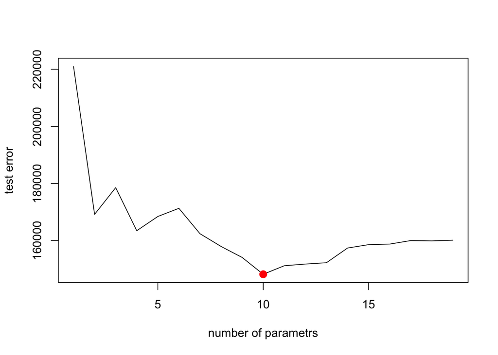

```r
plot(val.errors, ylab="test error", xlab="number of parametrs", type="l")
ve_min <- which.min(val.errors)
points(ve_min,val.errors[ve_min],col="red", cex=2, pch=20)
```

```r
ve_min
```

```
## [1] 10
```

```r
coef(regfit.best,id=ve_min)
```

```
## (Intercept)       AtBat        Hits       Walks      CAtBat       CHits
## -80.2751499  -1.4683816   7.1625314   3.6430345  -0.1855698   1.1053238
##      CHmRun      CWalks     LeagueN   DivisionW     PutOuts
##   1.3844863  -0.7483170  84.5576103 -53.0289658   0.2381662
```

Lets write a function for `predict.regsubsets`

```r
#syntax is complex
predict.regsubsets<-function(object,newdata,id,...){
    form<-as.formula(object$call[[2]])
    mat<-model.matrix(form,newdata)
    coefi<-coef(object,id=id)
    mat[,names(coefi)]%*%coefi
}
```

Lets use it in the k-fold validation .

```r
k<-10
set.seed(1)
folds<-sample(1:k, nrow(Hitters), replace=TRUE)
table(folds) # to see the frequency of echh element of a sequence 1:10
```

```
## folds
##  1  2  3  4  5  6  7  8  9 10
## 13 25 31 32 33 27 26 30 22 24
```

```r
#prepare a matrix to store  cross validation errors
cv.errors <- matrix(NA,k,p_features, dimnames=list(NULL,paste(1:19)))

#looping on  k folds
for(j in 1:k ){
  #method best model selection (cpu consuming)
    best.fit <- regsubsets(Salary~.,data=Hitters[folds!=j,] ,nvmax=p_features)
       #loop through possible model sizes on test data
    for(i in 1:19){
        pred<-predict.regsubsets(best.fit, Hitters[folds==j,], id=i)
        cv.errors[j,i]<-mean( (Hitters$Salary[folds==j]-pred)^2)
   }
}
#obtain a mean cv error
mean.cv.errors <- apply(cv.errors, MARGIN=2, mean) #apply func mean on index 2 (columns)
str(mean.cv.errors)
```

```
##  Named num [1:19] 160093 140197 153117 151159 146841 ...
##  - attr(*, "names")= chr [1:19] "1" "2" "3" "4" ...
```

```r
print(paste("mean cv error:", paste(mean.cv.errors, collapse=",")))
```

```
## [1] "mean cv error: 160093.486398318,140196.773091529,153116.968353284,151159.338649923,146841.301803275,138302.632366087,144346.225347738,130207.693625525,129459.613710927,125334.660569683,125153.816649585,128273.547905646,133461.030824061,133974.608481698,131825.723993328,131882.769468209,13275…
```

Lets make a plot of cv curve and determinte the minumum CVE.

```r
plot(mean.cv.errors, type='b', main="cross-validation curve for best subset selection", xlab="Number of Variables")
min_cve_idx <- which.min(as.numeric(mean.cv.errors))
paste("min CVE found for model size", min_cve_idx)
```

```
## [1] "min CVE found for model size 11"
```

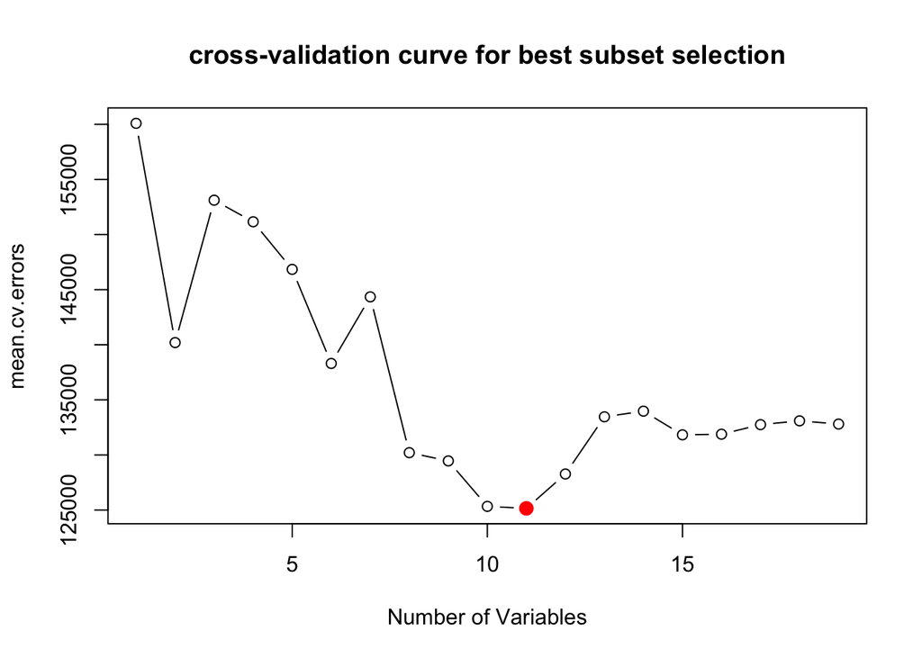

```r
points(min_cve_idx, mean.cv.errors[min_cve_idx],col="red", cex=2, pch=20)
```

## Lab 2: Ridge Regression and Lasso

`glmnet` package will be used fro Ridge and Lasso. `model.matrix` will be used to transfor model in a matrix form. This function also transforms any qualitataive variables into dummy variables

```r
x <- model.matrix(Salary~. ,data=Hitters)[,-1] #syntax different in lecture
y <- Hitters$Salary
```

### Ridge Regresssion

```r
library(glmnet)
```

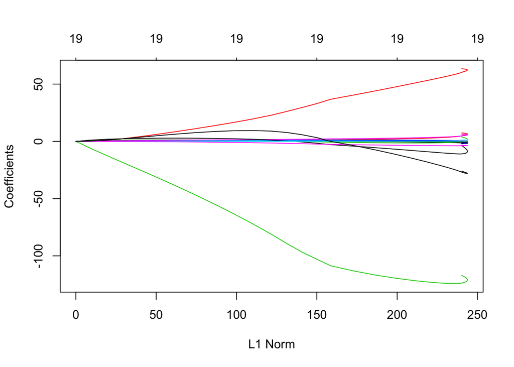

```r
grid <- 10^seq(10,-2,length=100) # array of 100 values from 10^10 to 10^-2 for lambda
# by default glmnet standardize variables
ridge.mod <- glmnet(x,y, alpha=0, lambda=grid) # alpha = 0  is ridge
plot(ridge.mod)
```

```r
ridge.mod$lambda[50] #lambda from the middle of the grid
```

```
## [1] 11497.57
```

```r
coef(ridge.mod)[,50] #model coefficients for lambda from the middle of the grid
```

```
##   (Intercept)         AtBat          Hits         HmRun          Runs
## 407.356050200   0.036957182   0.138180344   0.524629976   0.230701523
##           RBI         Walks         Years        CAtBat         CHits
##   0.239841459   0.289618741   1.107702929   0.003131815   0.011653637
##        CHmRun         CRuns          CRBI        CWalks       LeagueN
##   0.087545670   0.023379882   0.024138320   0.025015421   0.085028114
##     DivisionW       PutOuts       Assists        Errors    NewLeagueN
##  -6.215440973   0.016482577   0.002612988  -0.020502690   0.301433531
```

```r
#compute the l2 norm
sqrt(sum(coef(ridge.mod)[-1,50]^2))
```

```
## [1] 6.360612
```

```r
dim(coef(ridge.mod))
```

```
## [1]  20 100
```

We can also get coefficients using `predict` e.g. for $\lambda=50$

```r
predict(ridge.mod, s=50,type="coefficients")[1:20,]
```

```
##   (Intercept)         AtBat          Hits         HmRun          Runs
##  4.876610e+01 -3.580999e-01  1.969359e+00 -1.278248e+00  1.145892e+00
##           RBI         Walks         Years        CAtBat         CHits
##  8.038292e-01  2.716186e+00 -6.218319e+00  5.447837e-03  1.064895e-01
##        CHmRun         CRuns          CRBI        CWalks       LeagueN
##  6.244860e-01  2.214985e-01  2.186914e-01 -1.500245e-01  4.592589e+01
##     DivisionW       PutOuts       Assists        Errors    NewLeagueN
## -1.182011e+02  2.502322e-01  1.215665e-01 -3.278600e+00 -9.496680e+00
```

We now split data into a training set and a test set

```r
set.seed(1)
#split in half
full_idx <- 1:nrow(x)
train <- sample(full_idx, length(full_idx)/2 )
test <- full_idx[-train]
y.test <- y[test]
#observe train and test set (indexes)
#sort(train)
#sort(test)
```

Then we fit a ridge on the training set and evaluate its MSE on the test set using $\lambda = 4$

```r
#fit ridge on train
ridge.mod <- glmnet(x[train,], y[train], alpha=0, lambda = grid, thresh=1e-12 ) #alpha=0 is ridge
ridge.pred <- predict(ridge.mod, s=4, newx=x[test,]) #make predictions for lambda = 4
mse_lambda_4 <- mean((ridge.pred-y.test)^2) #mse on test for lambda = 4
mse_lambda_4
```

```
## [1] 101036.8
```

Lets compapre this MSE of $\lambda=4$ to cases with null model (only intercept) and to MSE of $\lambda=0$

```r
#compute mse of the null model (only intercept as param)
mse_nullmodel <- mean( (mean(y[train])-y.test)^2 )
#predict for lambda = 10^10
ridge.pred <- predict(ridge.mod, s=1e10, newx=x[test,])
mse_lambda_inf <- mean((ridge.pred-y.test)^2)

#predict mse  for lambda = 0
ridge.pred <- predict(ridge.mod, s=0, newx=x[test,])
mse_lambda_zero <- mean((ridge.pred-y.test)^2)

#lets compare mses
paste("mse of null model:",mse_nullmodel
      ,"mse of lambda very large:",mse_lambda_inf
      ,"mse of lambda 0:", mse_lambda_zero
      ,"mse of lambda 4:",mse_lambda_4)
```

```
## [1] "mse of null model: 193253.113067991 mse of lambda very large: 193253.05679545 mse of lambda 0: 114723.615178307 mse of lambda 4: 101036.832669597"
```

We observe that the case of lambda 4 has a much lower MSE compared to full collapse of parameters ($\lambda -> \infty$) and no collapse of parameters ($\lambda =0$).

Lets verify that coefficients of ridge with $\lambda=0$ correspond to a classical linear regression. It is still advised to use `lm()` for linear regression as this function generates also p-values.

```r
lm.reg<-lm(y~x, subset=train)
print(lm.reg)
```

```
##
## Call:
## lm(formula = y ~ x, subset = train)
##
## Coefficients:
## (Intercept)       xAtBat        xHits       xHmRun        xRuns
##   299.42849     -2.54027      8.36682     11.64512     -9.09923
##        xRBI       xWalks       xYears      xCAtBat       xCHits
##     2.44105      9.23440    -22.93673     -0.18154     -0.11598
##     xCHmRun       xCRuns        xCRBI      xCWalks     xLeagueN
##    -1.33888      3.32838      0.07536     -1.07841     59.76065
##  xDivisionW     xPutOuts     xAssists      xErrors  xNewLeagueN
##   -98.86233      0.34087      0.34165     -0.64207     -0.67442
```

```r
#note exact=TRUE param
#print(predict(ridge.mod, s=0, exact=TRUE, type="coefficients")[1:20,] ) #produces error
print(predict(ridge.mod, s=0, type="coefficients")[1:20,] )
```

```
##  (Intercept)        AtBat         Hits        HmRun         Runs
## 299.44467220  -2.53538355   8.33585019  11.59830815  -9.05971371
##          RBI        Walks        Years       CAtBat        CHits
##   2.45326546   9.21776006 -22.98239583  -0.18191651  -0.10565688
##       CHmRun        CRuns         CRBI       CWalks      LeagueN
##  -1.31721358   3.31152519   0.06590689  -1.07244477  59.75587273
##    DivisionW      PutOuts      Assists       Errors   NewLeagueN
## -98.94393005   0.34083276   0.34155445  -0.65312471  -0.65882930
```

We observe that coefficients are very similar.

Now lets find a minimal test MSE using a cross validation using `cv.glmnet()`.

```r
set.seed(1)
cv.out <- cv.glmnet(x[train,], y[train], alpha=0)
bestlam<-cv.out$lambda.min
bestlam
```

```
## [1] 211.7416
```

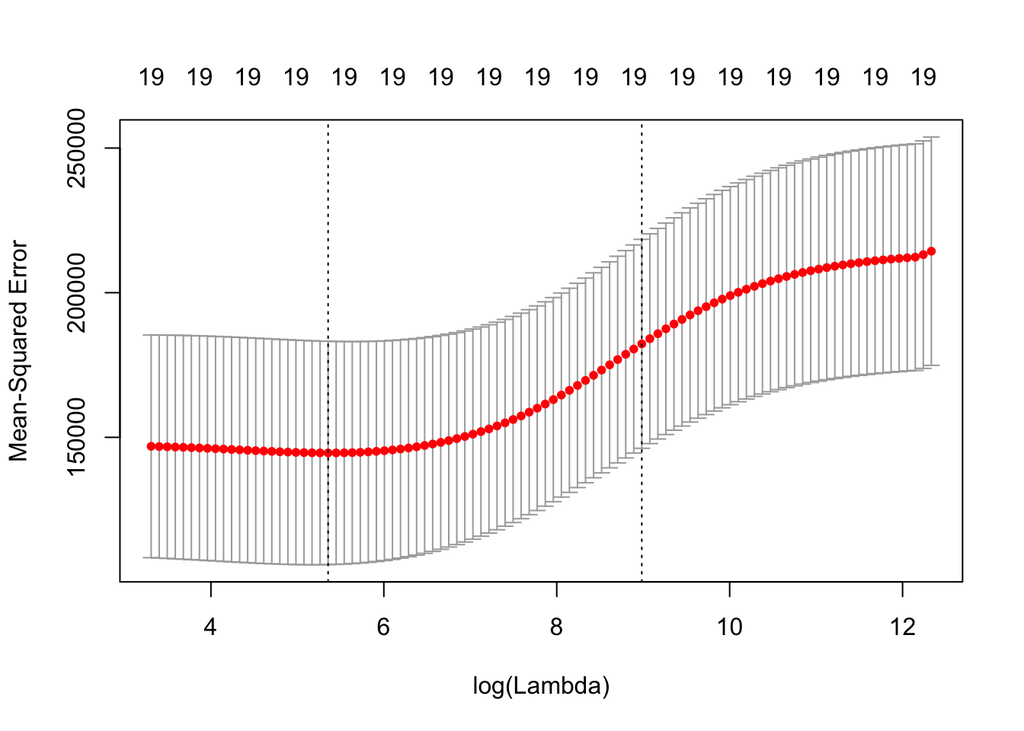

```r
plot(cv.out)
```

```r
#the test MSE for best lambda
ridge.pred <- predict(ridge.mod, s=bestlam, newx=x[test,])
bestlam_mse <- mean((ridge.pred-y.test)^2)
bestlam_mse
```

```
## [1] 96015.51
```

If we print model coefficients with best determined lamba, we see that none of them is zero. Thus the ridge regularisation does not shrink the model.

```r
out=glmnet(x,y,alpha=0)
coefs<-predict(out,type="coefficients",s=bestlam)[1:20,]
coefs
```

```
##  (Intercept)        AtBat         Hits        HmRun         Runs
##   9.88487157   0.03143991   1.00882875   0.13927624   1.11320781
##          RBI        Walks        Years       CAtBat        CHits
##   0.87318990   1.80410229   0.13074381   0.01113978   0.06489843
##       CHmRun        CRuns         CRBI       CWalks      LeagueN
##   0.45158546   0.12900049   0.13737712   0.02908572  27.18227535
##    DivisionW      PutOuts      Assists       Errors   NewLeagueN
## -91.63411299   0.19149252   0.04254536  -1.81244470   7.21208390
```

### The Lasso Regression

Same fuctions are uses as with Ridge except the parameter `alpha=1`

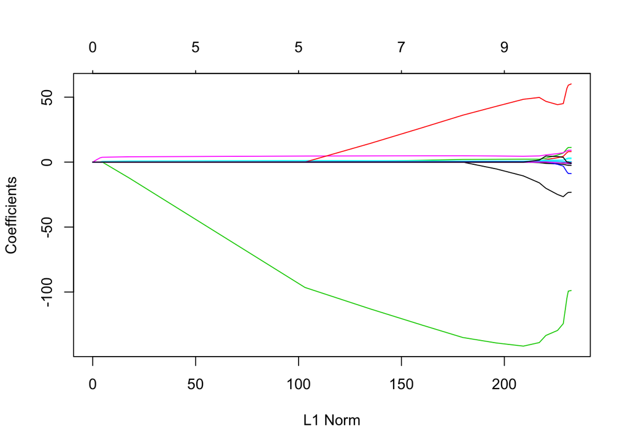

```r
lasso.mod=glmnet(x[train ,],y[train],alpha=1,lambda=grid)
plot(lasso.mod)
```

Lets compute the best lambda and MSE usng the cross validation as for the Ridge.

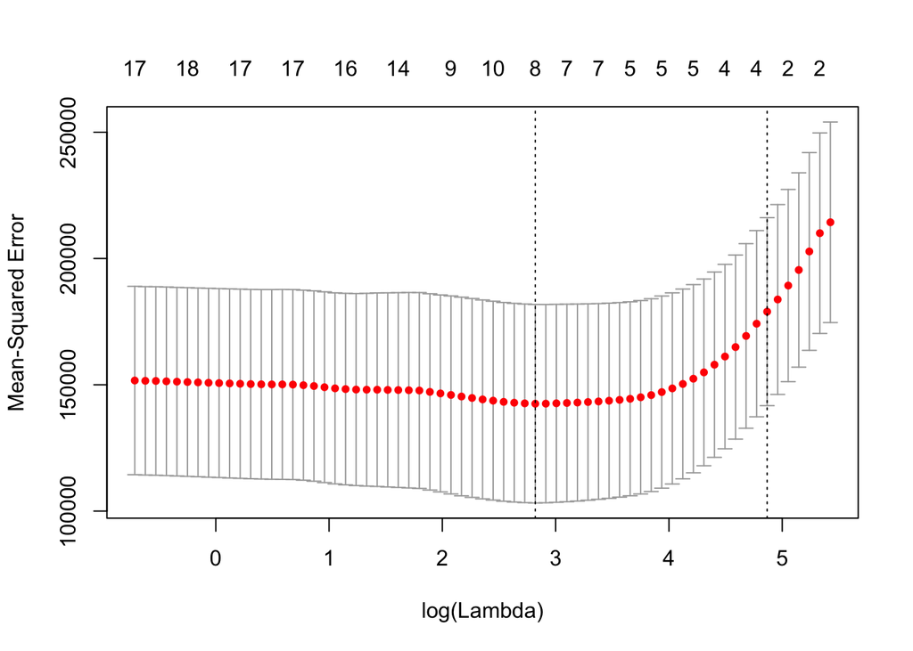

```r
set.seed (1)
cv.out <- cv.glmnet(x[train,], y[train],alpha=1)
plot(cv.out)
```

```r
bestlam=cv.out$lambda.min
print(bestlam)
```

```
## [1] 16.78016
```

```r
lasso.pred=predict(lasso.mod,s=bestlam ,newx=x[test,])
mse_bestlam_lasso <- mean((lasso.pred-y.test)^2)
print(mse_bestlam_lasso)
```

```
## [1] 100743.4
```

We see that the best Lasso MSE is very similar as best Ridge MSE.

Now lets see how lasso shrinks the model,

```r
out <- glmnet(x,y, alpha=1, lambda=grid)
lasso.coef <- predict(out, type="coefficients", s=bestlam)[1:20,]
print(lasso.coef)
```

```
##  (Intercept)        AtBat         Hits        HmRun         Runs
##   18.5394844    0.0000000    1.8735390    0.0000000    0.0000000
##          RBI        Walks        Years       CAtBat        CHits
##    0.0000000    2.2178444    0.0000000    0.0000000    0.0000000
##       CHmRun        CRuns         CRBI       CWalks      LeagueN
##    0.0000000    0.2071252    0.4130132    0.0000000    3.2666677
##    DivisionW      PutOuts      Assists       Errors   NewLeagueN
## -103.4845458    0.2204284    0.0000000    0.0000000    0.0000000
```

```r
print(lasso.coef[lasso.coef != 0])
```

```
##  (Intercept)         Hits        Walks        CRuns         CRBI
##   18.5394844    1.8735390    2.2178444    0.2071252    0.4130132
##      LeagueN    DivisionW      PutOuts
##    3.2666677 -103.4845458    0.2204284
```

We observe that for the best $\lambda$ the model has only 7 variables (out of 19).

## Lab 3: PCR and PLS Regression

#### PCR: Principal Components Regression

Package `pls` is used forPCR and PLS Rgressions. Lets make the pcr fit on all daa and observe it summary

```r
library(pls)
set.seed(2)
pcr.fit=pcr(Salary~., data=Hitters ,scale=TRUE,validation ="CV") #scale=T normalizes predictors
print(summary(pcr.fit))
```

```
## Data:    X dimension: 263 19
##  Y dimension: 263 1
## Fit method: svdpc
## Number of components considered: 19
##
## VALIDATION: RMSEP
## Cross-validated using 10 random segments.
##        (Intercept)  1 comps  2 comps  3 comps  4 comps  5 comps  6 comps
## CV             452    348.9    352.2    353.5    352.8    350.1    349.1
## adjCV          452    348.7    351.8    352.9    352.1    349.3    348.0
##        7 comps  8 comps  9 comps  10 comps  11 comps  12 comps  13 comps
## CV       349.6    350.9    352.9     353.8     355.0     356.2     363.5
## adjCV    348.5    349.8    351.6     352.3     353.4     354.5     361.6
##        14 comps  15 comps  16 comps  17 comps  18 comps  19 comps
## CV        355.2     357.4     347.6     350.1     349.2     352.6
## adjCV     352.8     355.2     345.5     347.6     346.7     349.8
##
## TRAINING: % variance explained
##         1 comps  2 comps  3 comps  4 comps  5 comps  6 comps  7 comps
## X         38.31    60.16    70.84    79.03    84.29    88.63    92.26
## Salary    40.63    41.58    42.17    43.22    44.90    46.48    46.69
##         8 comps  9 comps  10 comps  11 comps  12 comps  13 comps  14 comps
## X         94.96    96.28     97.26     97.98     98.65     99.15     99.47
## Salary    46.75    46.86     47.76     47.82     47.85     48.10     50.40
##         15 comps  16 comps  17 comps  18 comps  19 comps
## X          99.75     99.89     99.97     99.99    100.00
## Salary     50.55     53.01     53.85     54.61     54.61
## NULL
```

Observe that `pcr()` reports the root mean squared error; in order to obtain the usual MSE, we must square this quantity.

In the variance exmplined section the `X` is the amount of information about the model predictors captured by components. `Salary` shows the variance explained for the model response variable.

We can plot the cross-validation scores.

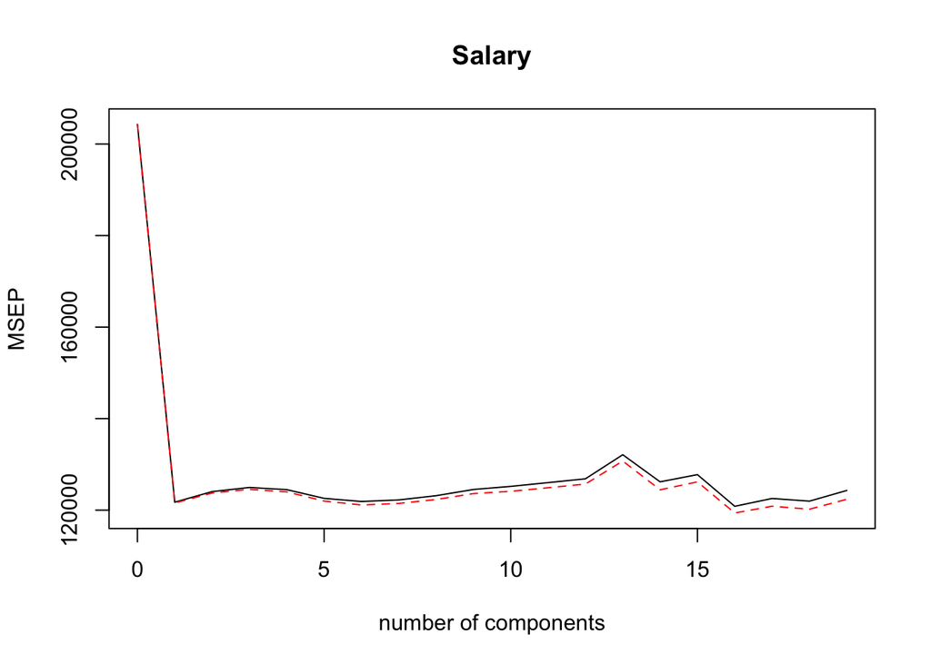

```r
validationplot(pcr.fit, val.type="MSEP") #MSEP - cross-validation MSE to be plotted
```

Now we perform pcr on the training data and evaluate its test MSE.

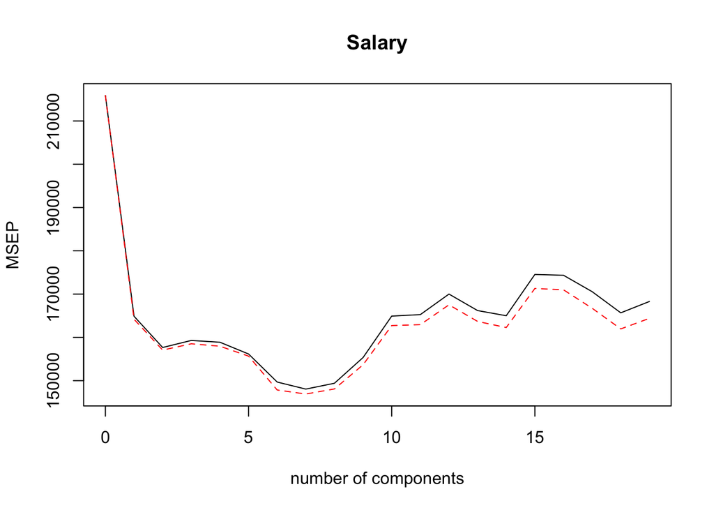

```r
set.seed(1)
pcr.fit=pcr(Salary~., data=Hitters,subset=train,scale=TRUE,validation ="CV")
validationplot(pcr.fit,val.type="MSEP")
```

We observe from the plot the min of CV error is when the number of componenets equals 7. Lets find the correspoinding test MSE.

```r
pcr.pred <- predict(pcr.fit, x[test,], ncomp=7)
mse_test_min <- mean((pcr.pred-y.test)^2)
mse_test_min
```

```
## [1] 96556.22
```

We fit PCR on the full data set, using M = 7, the number of components identified by cross-validation.

```r
pcr.fit <- pcr(y~x, scale=TRUE, ncomp=7) #on all dataset on 7 componentts
print(summary(pcr.fit))
```

```
## Data:    X dimension: 263 19
##  Y dimension: 263 1
## Fit method: svdpc
## Number of components considered: 7
## TRAINING: % variance explained
##    1 comps  2 comps  3 comps  4 comps  5 comps  6 comps  7 comps
## X    38.31    60.16    70.84    79.03    84.29    88.63    92.26
## y    40.63    41.58    42.17    43.22    44.90    46.48    46.69
## NULL
```

#### PLS: Partial Least Squares Regression

Partial least squares is available in the same `pls` package and uses the same syntax.

```r
set.seed (1)
pls.fit=plsr(Salary~., data=Hitters, subset=train, scale=TRUE, validation="CV")
print(summary(pls.fit))
```

```
## Data:    X dimension: 131 19
##  Y dimension: 131 1
## Fit method: kernelpls
## Number of components considered: 19
##
## VALIDATION: RMSEP
## Cross-validated using 10 random segments.
##        (Intercept)  1 comps  2 comps  3 comps  4 comps  5 comps  6 comps
## CV           464.6    394.2    391.5    393.1    395.0    415.0    424.0
## adjCV        464.6    393.4    390.2    391.1    392.9    411.5    418.8
##        7 comps  8 comps  9 comps  10 comps  11 comps  12 comps  13 comps
## CV       424.5    415.8    404.6     407.1     412.0     414.4     410.3
## adjCV    418.9    411.4    400.7     402.2     407.2     409.3     405.6
##        14 comps  15 comps  16 comps  17 comps  18 comps  19 comps
## CV        406.2     408.6     410.5     408.8     407.8     410.2
## adjCV     401.8     403.9     405.6     404.1     403.2     405.5
##
## TRAINING: % variance explained
##         1 comps  2 comps  3 comps  4 comps  5 comps  6 comps  7 comps
## X         38.12    53.46    66.05    74.49    79.33    84.56    87.09
## Salary    33.58    38.96    41.57    42.43    44.04    45.59    47.05
##         8 comps  9 comps  10 comps  11 comps  12 comps  13 comps  14 comps
## X         90.74    92.55     93.94     97.23     97.88     98.35     98.85
## Salary    47.53    48.42     49.68     50.04     50.54     50.78     50.92
##         15 comps  16 comps  17 comps  18 comps  19 comps
## X          99.11     99.43     99.78     99.99    100.00
## Salary     51.04     51.11     51.15     51.16     51.18
## NULL
```

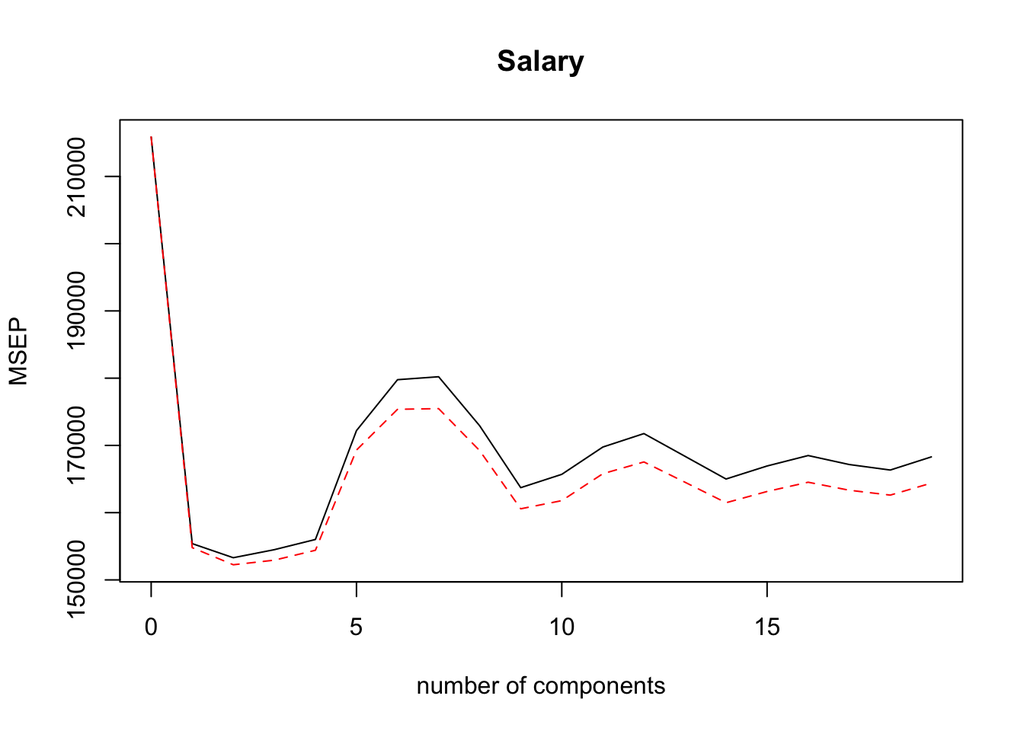

```r
validationplot(pls.fit,val.type="MSEP")
```

We see that minimum of MSE happens for number of components M=2. Lets compute the corresponding test MSE.

```r
pls.pred <- predict(pls.fit, x[test,], ncomp=2)
mse_test_min <- mean((pls.pred-y.test)^2)
print(mse_test_min)
```

```
## [1] 101417.5
```

This test MSE is comparable but slightly higher that, the test MSE of ridge, lasso and PCR. Lets do a pls fit on the whole data using a found number of components M=2

```r
pls.fit <- plsr(Salary~., data=Hitters, scale=TRUE, ncomp=2)
print(summary(pls.fit))
```

```
## Data:    X dimension: 263 19
##  Y dimension: 263 1
## Fit method: kernelpls
## Number of components considered: 2
## TRAINING: % variance explained
##         1 comps  2 comps
## X         38.08    51.03
## Salary    43.05    46.40
## NULL
```

In PLS with 2 components almost the same amount of variance is exaplained was with 7 components of PCR.